# PHS Scotland Task

Jonny Nelson

# Task

#### *Task* - Gain better understanding of the incidence of cancer in NHS Borders

#### *Outcome* - Help inform the planning for provision of cancer treatment

# Overall Trend in Borders Crude Rate per 100,000

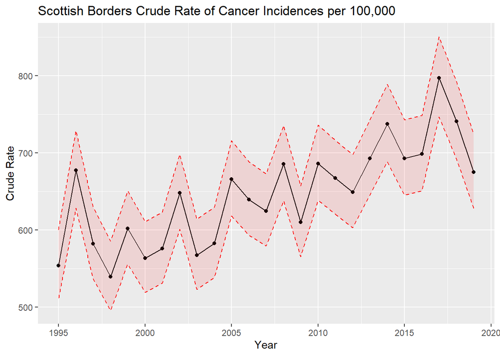

#### - Initial cleaning of the data set to mutate in a new variable to show the health boards by name and the clean the names of the variables into the tidy data format.

#### - Firstly wanted to take a look at just the Borders in a time series idenifying the trend in the crude rate of cancer per 100,000.

#### - As we can see the trend clearly indicates an increase over time for All cancer types from 1995 to 2019

# Breakdowns by Cancer Type

#### - Next I wanted to identify the main drivers in this overall trend increase to get a better understanding of which specific types of cancer were driving the steady increase

#### - Plotting this out on a using the facet wrap gave too many graphs to be able to discern any trends. So I had to look about things in another way. Afterwards I figured out the solution was to make the plot into a function and then pass the function through plot_grid where you can select the plots shown.

| cancer_site | percent_change_in_incidences | absolute_change_in_incidences |
| --- | --- | --- |
| All brain and CNS tumours (malignant and non-malignant) | Inf | 23 |
| Non-malig brain ca (incl pit.gland,cranio.duct,pineal gland) | Inf | 10 |
| Salivary glands | Inf | 2 |
| Carcinoma in situ of the breast | 600.00000 | 6 |
| Tongue | 400.00000 | 4 |
| Connective tissue | 300.00000 | 3 |
| Liver and intrahepatic bile ducts | 200.00000 | 6 |
| Thyroid | 200.00000 | 2 |
| Multiple myeloma and malignant plasma cell neoplasms | 166.66667 | 10 |
| Oropharyngeal cancers | 120.00000 | 6 |
| Kidney | 110.00000 | 11 |
| Bone and connective tissue | 100.00000 | 2 |
| Chronic lymphocytic leukaemia | 100.00000 | 7 |
| Basal cell carcinoma of the skin | 93.91304 | 108 |
| Non-melanoma skin cancer | 88.06818 | 155 |
| Pancreas | 83.33333 | 15 |
| Breast | 75.00000 | 42 |
| Lip, oral cavity and pharynx | 75.00000 | 9 |
| Squamous cell carcinoma of the skin | 70.49180 | 43 |
| Acute lymphoblastic leukaemia | 50.00000 | 1 |
| Malignant melanoma of the skin | 48.00000 | 12 |

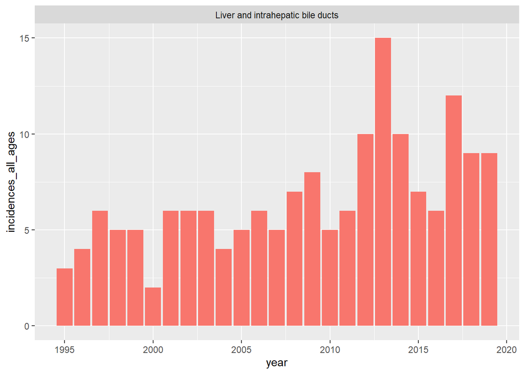

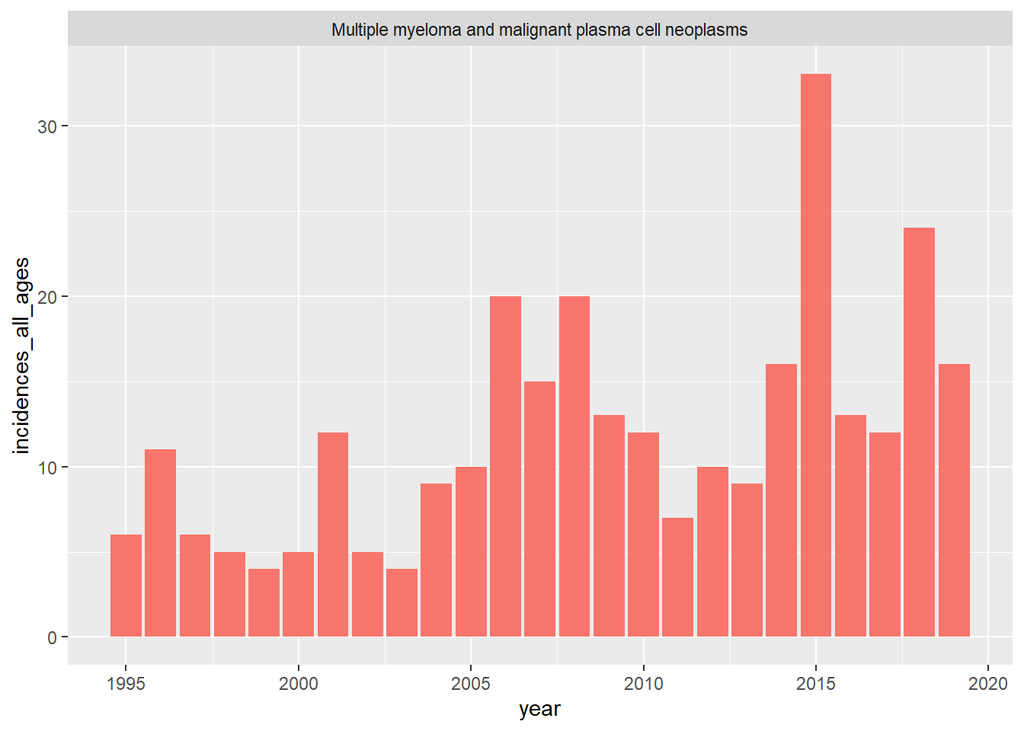

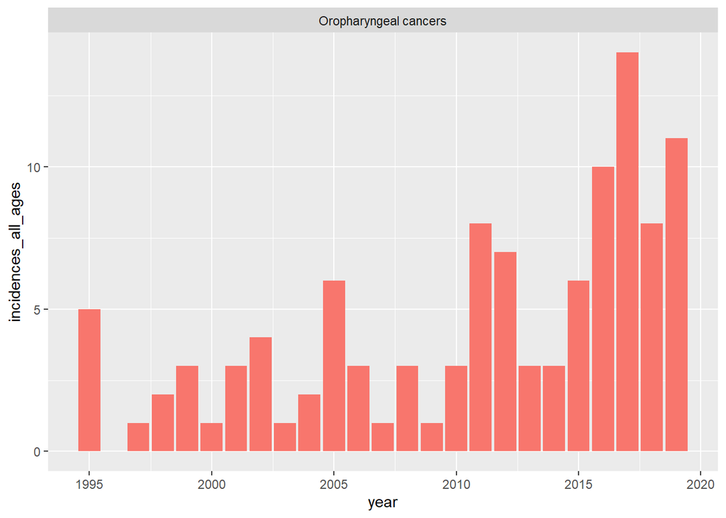

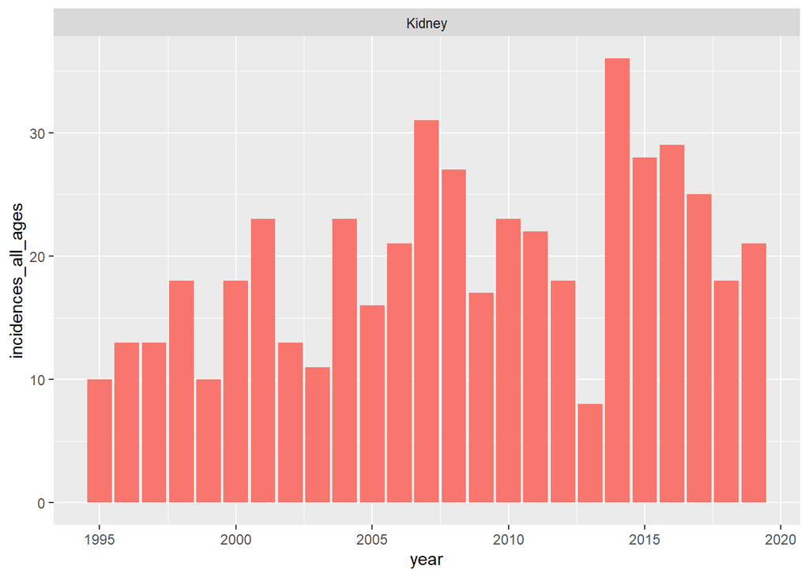

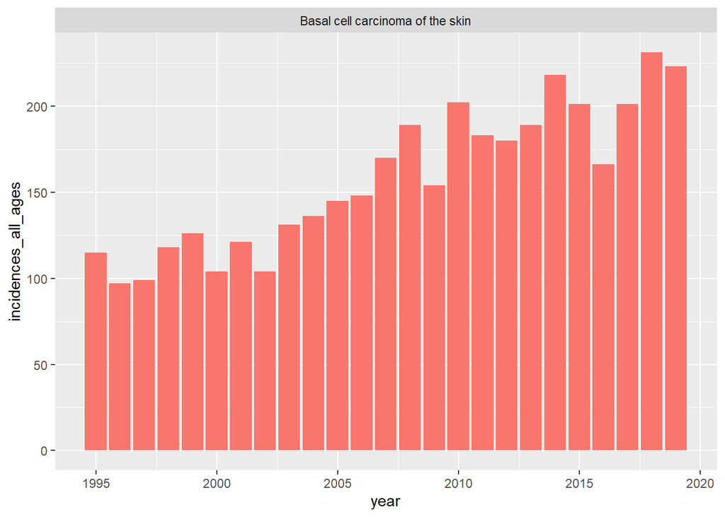

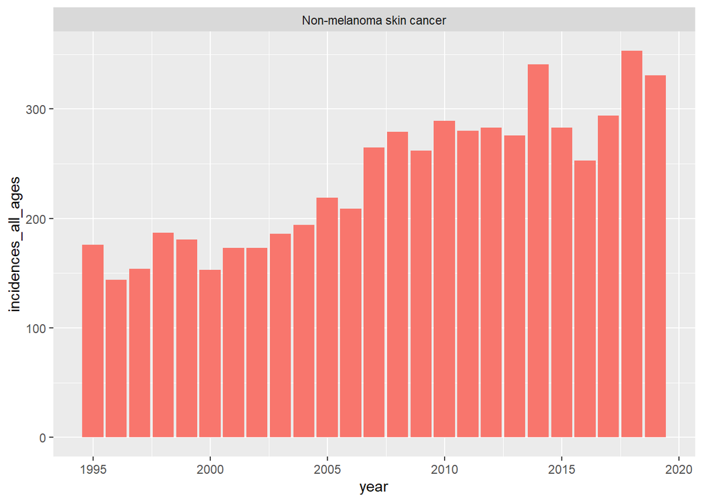

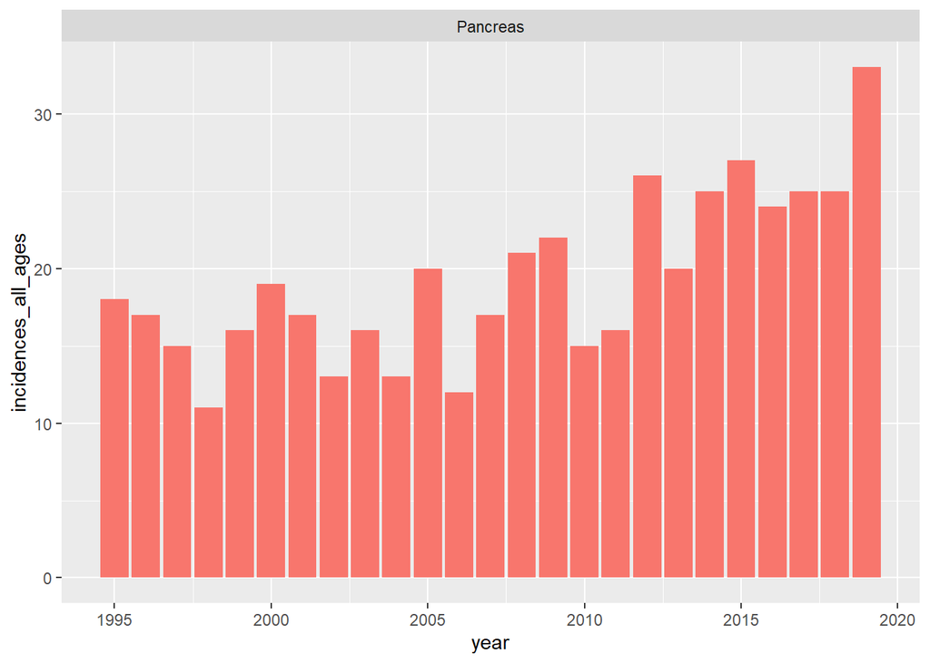

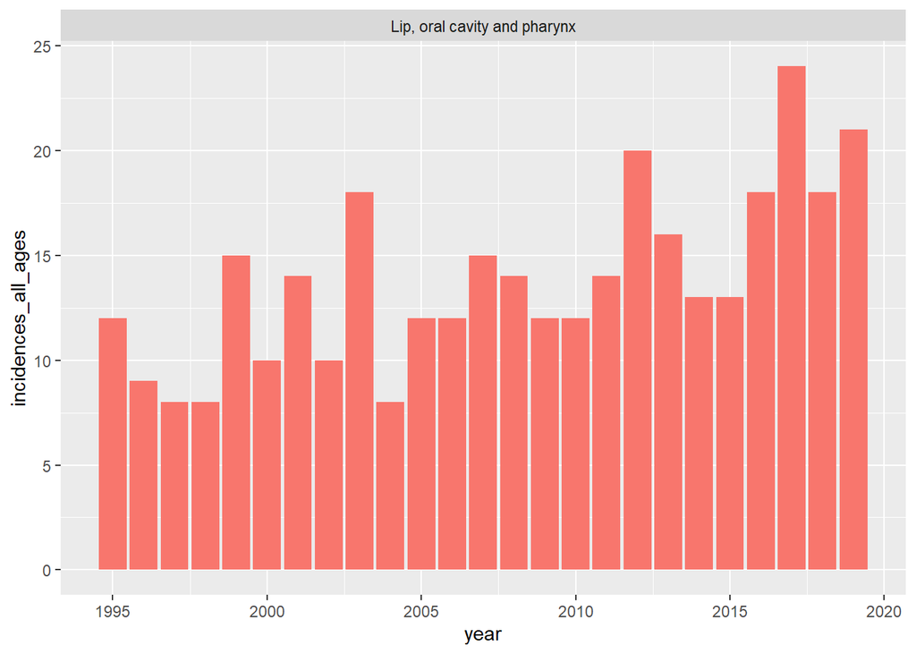

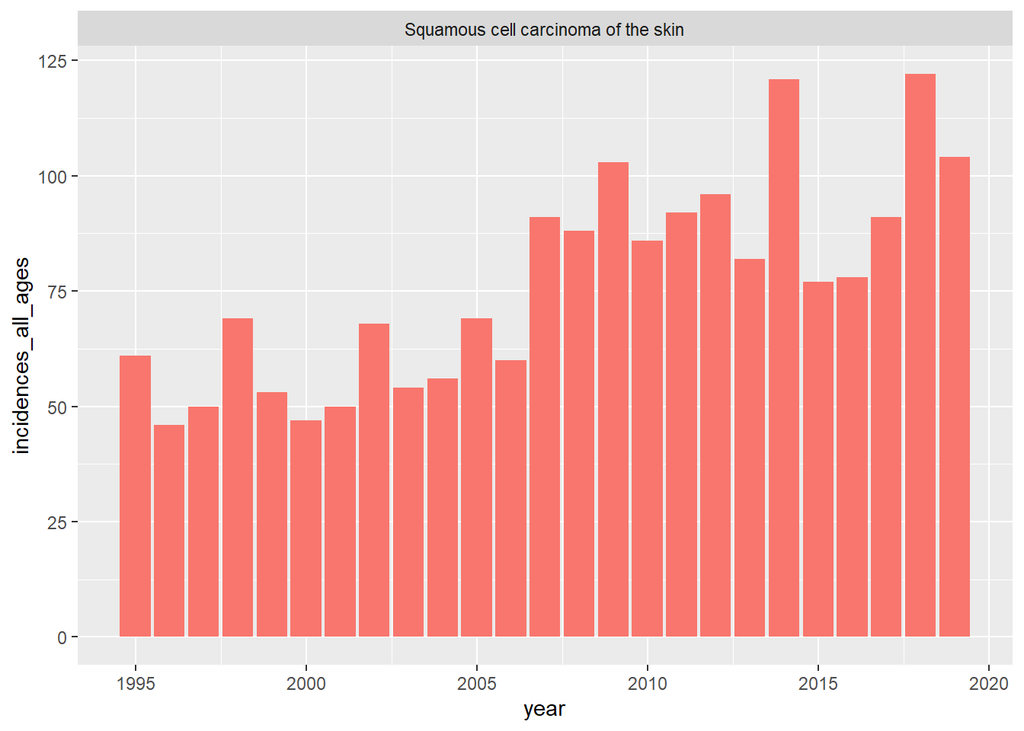

#### - This could be very helpful to supply chain teams within hospitals who need to provision the treatments for these types of cancer.

#### - It would also inform hospital management and specialists on how they would be able to manage say, increased chemotherapy, for these expected patients.

#### - This could inform NHS Borders public health policy and messaging. There may be increased cancer awareness and early detection targeting these cancer types - informed by specialists and consultants - with what to look out for.

# Continuation:

#### - For the future, could use the age range statistics to inform what ages and sexs need targeting for messaging

#### - Breakdowns of Borders vs. Scotland vs. Europe